# Project Objective: Differential Weed from Crop Seedling.

### #1. Import the libraries, load dataset, print shape of data, visualize the images in dataset.

```python
# Import necessary libraries.
import warnings
warnings.filterwarnings('ignore')
import cv2
import math
import numpy as np
import pandas as pd
from glob import glob
import seaborn as sns
from matplotlib import pyplot as plt
%matplotlib inline

import tensorflow as tf
from tensorflow.keras.models import Sequential
from tensorflow.keras.layers import (
    Dense,
    Dropout,
    Flatten,
    Conv2D,
    MaxPooling2D,
    MaxPool2D,
    GlobalMaxPooling2D,
    BatchNormalization
)
from tensorflow.keras.layers import BatchNormalization
from tensorflow.keras.optimizers import RMSprop, Adam
from keras.utils.np_utils import to_categorical # convert to one-hot-encoding
from tensorflow.keras.preprocessing.image import ImageDataGenerator

from sklearn.model_selection import train_test_split
from tensorflow.keras.callbacks import EarlyStopping, ModelCheckpoint
from sklearn.metrics import classification_report, confusion_matrix
from google.colab.patches import cv2_imshow
```

```python
from google.colab import drive
drive.mount('/content/drive')
```

### Load Dataset

```python
y_label = pd.read_csv("/content/drive/My Drive/Colab Notebooks/Labels.csv")
x_img= np.load("/content/drive/My Drive/Colab Notebooks/images.npy")
```

### Print shape of data

```python
print("x_img shape:", x_img.shape)
print("Nos. of Image sample", x_img.shape[0])
```

```
x_img shape: (4750, 128, 128, 3)
Nos. of Image sample 4750
```

Note:

1. There are 4750 images
2. The size of the image is 128 by 128
3. The images are colored.

```python
#check the length of the training images for confirmation
len(x_img)
```

```
4750
```

```python
#check the length of the labels for confirmation
len(y_label)
```

```
4750
```

```python
type(x_img) # verifing the data type
```

```
numpy.ndarray
```

```python
y_label.head(3) # reading the head label
```

|  | Label |
| --- | --- |
| 0 | Small-flowered Cranesbill |
| 1 | Small-flowered Cranesbill |
| 2 | Small-flowered Cranesbill |

```python
y_label.tail(3) # label tail
```

|  | Label |
| --- | --- |
| 4747 | Loose Silky-bent |
| 4748 | Loose Silky-bent |
| 4749 | Loose Silky-bent |

```python
Num_classes = len((x_img))
Num_classes = len(['Black-grass','Charlock','Cleavers','Common Chickweed','Common wheat','Fat Hen','Loose Silky-bent','Maize'
 ,'Scentless Mayweed','Shepherds Purse','Small-flowered Cranesbill','Sugar beet'])
Num_classes
```

```
12
```

```python
label_dict ={0:'Black-grass',1:'Charlock',2:'Cleavers',3:'Common Chickweed',4:'Common wheat',5:'Fat Hen',6:'Loose Silky-bent',7:'Maize'
 ,8:'Scentless Mayweed',9:'Shepherds Purse',10:'Small-flowered Cranesbill',11:'Sugar beet'}
```

```python
species = ['Black-grass', 'Charlock', 'Cleavers', 'Common Chickweed', 'Common wheat', 'Fat Hen',
          'Loose Silky-bent', 'Maize','Scentless Mayweed', 'Shepherds Purse',
          'Small-flowered Cranesbill', 'Sugar beet']
```

```python
y_label=y_label.astype('category')
```

```python
y_label.dtypes
```

```
Label    category
dtype: object
```

```python
for i in list(y_label.columns[y_label.dtypes=='category']):
    print(y_label[i].value_counts())
    print()
```

```
Loose Silky-bent             654
Common Chickweed             611
Scentless Mayweed            516
Small-flowered Cranesbill    496
Fat Hen                      475
Charlock                     390
Sugar beet                   385
Cleavers                     287
Black-grass                  263
Shepherds Purse              231
Maize                        221
Common wheat                 221
Name: Label, dtype: int64
```

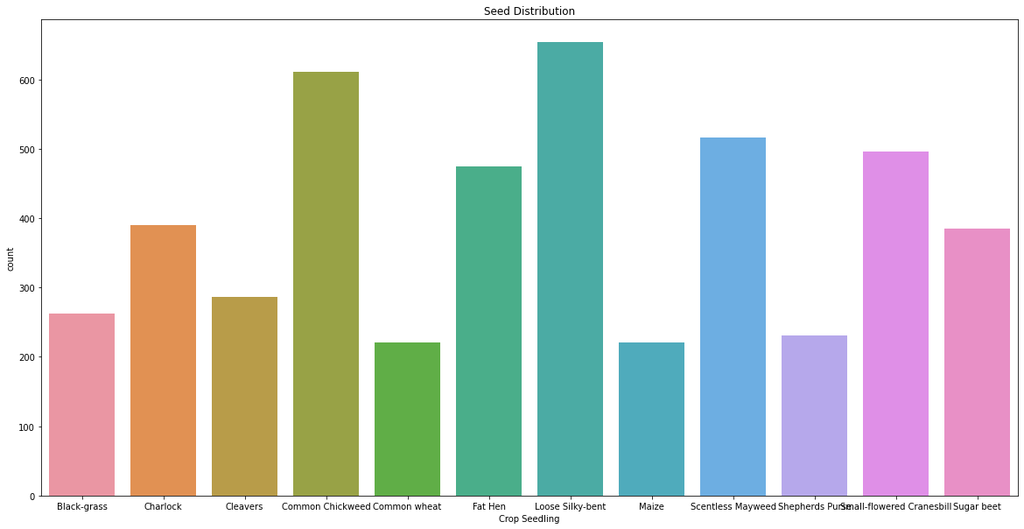

```python
plt.figure(figsize= (20,10))
sns.countplot(y_label["Label"])
plt.title("Seed Distribution")
plt.xlabel("Crop Seedling")
```

### visualize the images in dataset.

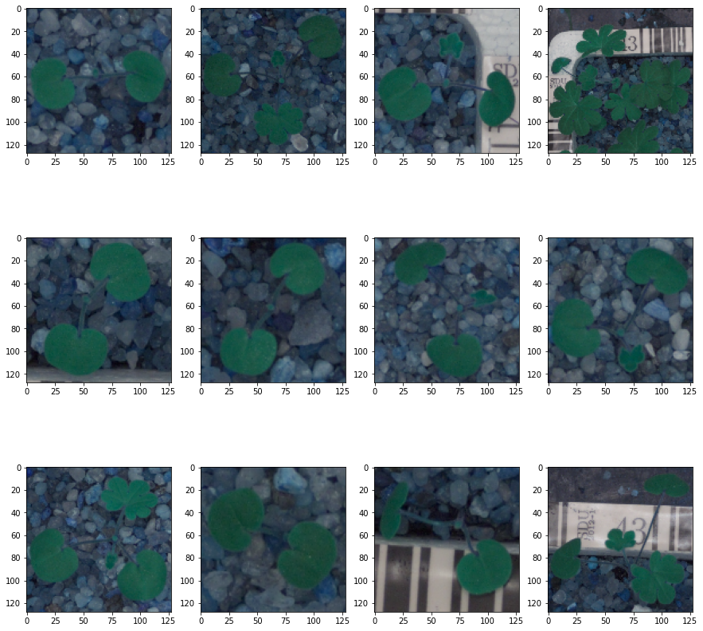

```python
#visualize the images in dataset
plt.figure(figsize= (15,15))
for i in range(12):
    plt.subplot(3, 4, i + 1)
    plt.imshow(x_img[i])
```

```
Image name:Small-flowered Cranesbill
```

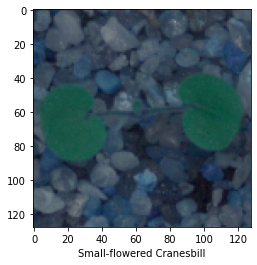

```python
# Sample Images
i = 0
img = x_img[i]
label = y_label.iloc[0][i]
print(f'Image name:{label}')
plt.imshow(img)
plt.xlabel(label)
```

```
Image name:Label    Common Chickweed
Name: 2000, dtype: category
Categories (12, object): ['Black-grass', 'Charlock', 'Cleavers', 'Common Chickweed', ...,
                          'Scentless Mayweed', 'Shepherds Purse', 'Small-flowered Cranesbill',
                          'Sugar beet']
```

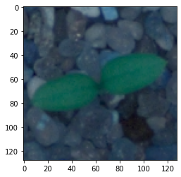

```python
i = 2000
img = x_img[i]
label = y_label.iloc[i]
print(f'Image name:{label}')
plt.imshow(img)
```

```
Image name:Label    Loose Silky-bent
Name: 4200, dtype: category
Categories (12, object): ['Black-grass', 'Charlock', 'Cleavers', 'Common Chickweed', ...,
                          'Scentless Mayweed', 'Shepherds Purse', 'Small-flowered Cranesbill',
                          'Sugar beet']
```

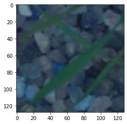

```python
i = 4200
img = x_img[i]
label = y_label.iloc[i]
print(f'Image name:{label}')
plt.imshow(img)
```

Note: Runing samples on the image

1. Label 1 is "mall-flowered Cranesbill"
2. label 2000 is "Common Chickweed"
3. label 4200 is "Loose Silky-bent'

```
Clipping input data to the valid range for imshow with RGB data ([0..1] for floats or [0..255] for integers).
```

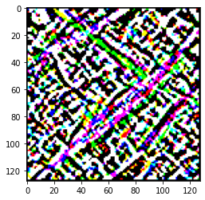

```python
# apply sobel for better visualization of the edges and capture by the model
img = x_img[i]
sobel = cv2.Sobel(img, cv2.CV_64F, 1, 1, ksize=5)
plt.imshow(sobel)
```

# **2. Data Pre-processing:**

- Normalization
- Gaussian Blurring.
- Visualize data after pre-processing.

a) Gaussian Blurring

Lets apply Gaussian Blurring to remove noise and get the edges of the images

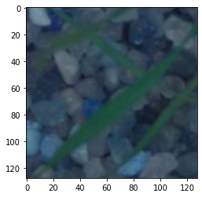

```python
#Preview the image before Gaussian Blur
plt.imshow(x_img[i], cmap='gray')
```

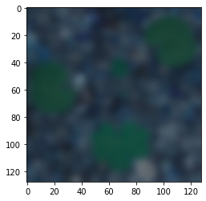

```python
plt.imshow(cv2.GaussianBlur(x_img[1], (15,15), 0)) #applying blurring
```

```python
# Now we apply the gaussian blur to each 128x128 pixels array (image) to reduce the noise in the image
for idx, img in enumerate(x_img):
  x_img[idx] = cv2.GaussianBlur(img, (5, 5), 0)
```

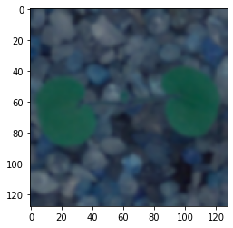

```python
# Visualize the image after Gaussian Blur
plt.imshow(x_img[0], cmap='gray')
```

Cleaning the images and removing the background:

Cleaning of the images is an intensive task. We will have to: Convert the RGB image into HSV. We will have to blur the image to remove noise. We will have to create a mask to remove the background.

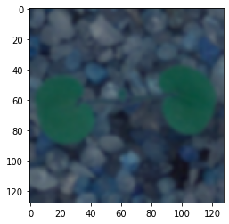

```python
# Visualize the image after Gaussian Blur
plt.imshow(x_img[0], cmap='gray')
```

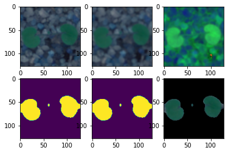

```python
clearTrainImg = []
examples = []; getEx = True
for img in x_img:
    # Use gaussian blur
    blurImg = cv2.GaussianBlur(img, (5, 5), 0)

    # Convert to HSV image
    hsvImg = cv2.cvtColor(blurImg, cv2.COLOR_BGR2HSV)

    # Create mask (parameters - green color range)
    lower_green = (25, 40, 50)
    upper_green = (75, 255, 255)
    mask = cv2.inRange(hsvImg, lower_green, upper_green)
    kernel = cv2.getStructuringElement(cv2.MORPH_ELLIPSE, (11, 11))
    mask = cv2.morphologyEx(mask, cv2.MORPH_CLOSE, kernel)

    # Create bool mask
    bMask = mask > 0

    # Apply the mask
    clear = np.zeros_like(img, np.uint8)  # Create empty image
    clear[bMask] = img[bMask]  # Apply boolean mask to the origin image

    clearTrainImg.append(clear)  # Append image without backgroung

    # Show examples
    if getEx:
        plt.subplot(2, 3, 1); plt.imshow(img)  # Show the original image
        plt.subplot(2, 3, 2); plt.imshow(blurImg)  # Blur image
        plt.subplot(2, 3, 3); plt.imshow(hsvImg)  # HSV image
        plt.subplot(2, 3, 4); plt.imshow(mask)  # Mask
        plt.subplot(2, 3, 5); plt.imshow(bMask)  # Boolean mask
        plt.subplot(2, 3, 6); plt.imshow(clear)  # Image without background
        getEx = False

clearTrainImg = np.asarray(clearTrainImg)
```

Note:

1. we use gaussian blur to remove noise
2. we conver color to HSV
3. We created a mask
4. We created a boolean mask
5. Apply boolen mask and getting image without background

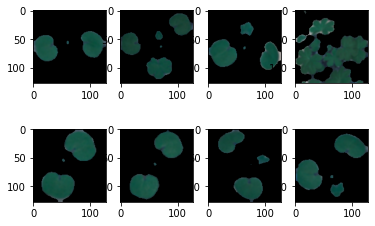

```python
# Show sample result
for i in range(8):
    plt.subplot(2, 4, i + 1)
    plt.imshow(clearTrainImg[i])
```

b)Normalization

```python
# normalize the training data
clearTrainImg = clearTrainImg/255
```

```python
x_img = clearTrainImg
```

```python
#Pixels are represented in the range [0-255],
#but the NN converges faster with smaller values, in the range [0-1].


# Check the nomalized data
print(f'Shape of the Train array:{x_img.shape}')
print(f'Minimum value in the Train Array:{x_img.min()}')
print(f'Maximum value in the Train Array:{x_img.max()}')
```

```
Shape of the Train array:(4750, 128, 128, 3)
Minimum value in the Train Array:0.0
Maximum value in the Train Array:0.9529411764705882
```

# **3. Make data compatible:**

One hot encode the label

```python
from sklearn.preprocessing import LabelBinarizer
encoder = LabelBinarizer()
y_label = encoder.fit_transform(y_label)
```

Print the label for y_train[0].

```python
print(y_label[0])
```

```
[0 0 0 0 0 0 0 0 0 0 1 0]
```

```python
# Step#1: Split train and test set
X_train, X_test, y_train, y_test = train_test_split(x_img, y_label, test_size=0.3, random_state=42)
```

```python
# Step#2: Split validation from test set
X_test, X_val, y_test, y_val = train_test_split(X_test, y_test, test_size=0.5, random_state=42)
```

**d. Check the shape of data, Reshape data into shapes compatible with Keras models if it’s not already. If it’s already in the compatible shape, then comment in the notebook that it’s already in compatible shape.**

```python
#Print shape
print('X_train shape : {}'.format(X_train.shape))
print('y_train shape : {}'.format(y_train.shape[0]))
print('X_test shape : {}'.format(X_test.shape))
print('y_test shape : {}'.format(y_test.shape[0]))
print('X_val shape : {}'.format(X_val.shape))
print('y_val shape : {}'.format(y_val.shape[0]))
```

```
X_train shape : (3325, 128, 128, 3)
y_train shape : 3325
X_test shape : (712, 128, 128, 3)
y_test shape : 712
X_val shape : (713, 128, 128, 3)
y_val shape : 713
```

Note:

Data is already shaped and normalize and fit for use, hence no need to reshape

```python
# Reshape data into shapes compatible with Keras models
from keras.preprocessing.image import ImageDataGenerator
datagen = ImageDataGenerator(
        rotation_range=180,  # randomly rotate images in the range
        zoom_range = 0.1, # Randomly zoom image
        width_shift_range=0.1,  # randomly shift images horizontally
        height_shift_range=0.1,  # randomly shift images vertically
        horizontal_flip=True,  # randomly flip images horizontally
        vertical_flip=True  # randomly flip images vertically
    )
datagen.fit(X_train)
X_train
```

[output not shown]

[output cut: 252 more lines]

[output not shown]

## 4. Building CNN:

1. Define layers.
2. Set optimizer and loss function. (Use Adam optimizer and categorical crossentropy

```python
def create_model(input_shape, num_classes):
  # Initialize CNN Classified
  model = Sequential()  # Instantiating the model

  # Add convolution layer with 32 filters and 3 kernels
  model.add(Conv2D(32, (3,3), input_shape=input_shape, padding='same', activation=tf.nn.relu)) # applying relu activation function on the Convolutional layer
  model.add(MaxPooling2D(pool_size=(2,2))) # performing dimension reduction using Maxpooling
  model.add(Dropout(rate=0.25)) # preventing overfitting of data by 25%

  # Add convolution layer with 32 filters and 3 kernels
  model.add(Conv2D(filters=32, kernel_size=3, padding='same', activation=tf.nn.relu))
  model.add(Conv2D(filters=64, kernel_size=3, padding='same', activation=tf.nn.relu))
  model.add(MaxPooling2D(pool_size=(2,2)))
  model.add(Dropout(rate=0.25))

  # Add convolution layer with 32 filters and 3 kernels
  model.add(Conv2D(filters=32, kernel_size=3, padding='same', activation=tf.nn.relu))
  model.add(MaxPooling2D(pool_size=(2,2)))
  model.add(Dropout(rate=0.25))

  # Flatten the 2D array to 1D array
  model.add(Flatten()) # flatten the volume to vector, for the dense layer to process

  # Create fully connected layers with 512 units
  model.add(Dense(512, activation=tf.nn.relu))
  model.add(Dropout(0.5))


  # Adding a fully connected layer with 128 neurons
  model.add(Dense(units = 128, activation = tf.nn.relu))
  model.add(Dropout(0.5))

  # The final output layer with 12 neurons to predict the categorical classifcation
  model.add(Dense(units = num_classes, activation = tf.nn.softmax))
  return model
```

```python
class myCallback(tf.keras.callbacks.Callback):
  def on_epoch_end(self, epoch, logs={}):
    if(logs.get('accuracy')>0.95):
      print("\nReached 95% accuracy so cancelling training!")
      self.model.stop_training = True

callbacks = myCallback()

es = EarlyStopping(monitor='val_accuracy', mode='min', verbose=1, patience=10)
```

```python
input_shape = X_train.shape[1:] # Input shape of X_train
num_classes = y_train.shape[1] # Target column size

model = create_model(input_shape, num_classes)
optimizer = tf.keras.optimizers.Adam(learning_rate=0.001) # Optimizer
# optimizer = tf.keras.optimizers.SGD(lr=1 * 1e-1, momentum=0.9, nesterov=True)

model.compile(optimizer=optimizer,
              loss='categorical_crossentropy',
              metrics=['accuracy'])

model.summary()
```

```
Model: "sequential"
_________________________________________________________________
Layer (type)                 Output Shape              Param #
=================================================================
conv2d (Conv2D)              (None, 128, 128, 32)      896
_________________________________________________________________
max_pooling2d (MaxPooling2D) (None, 64, 64, 32)        0
_________________________________________________________________
dropout (Dropout)            (None, 64, 64, 32)        0
_________________________________________________________________
conv2d_1 (Conv2D)            (None, 64, 64, 32)        9248
_________________________________________________________________
conv2d_2 (Conv2D)            (None, 64, 64, 64)        18496
_________________________________________________________________
max_pooling2d_1 (MaxPooling2 (None, 32, 32, 64)        0
_________________________________________________________________
dropout_1 (Dropout)          (None, 32, 32, 64)        0
_________________________________________________________________
conv2d_3 (Conv2D)            (None, 32, 32, 32)        18464
_________________________________________________________________
max_pooling2d_2 (MaxPooling2 (None, 16, 16, 32)        0
_________________________________________________________________
dropout_2 (Dropout)          (None, 16, 16, 32)        0
_________________________________________________________________
flatten (Flatten)            (None, 8192)              0
_________________________________________________________________
dense (Dense)                (None, 512)               4194816
_________________________________________________________________
dropout_3 (Dropout)          (None, 512)               0
_________________________________________________________________
dense_1 (Dense)              (None, 128)               65664
_________________________________________________________________
dropout_4 (Dropout)          (None, 128)               0
_________________________________________________________________
dense_2 (Dense)              (None, 12)                1548
=================================================================
Total params: 4,309,132
Trainable params: 4,309,132
Non-trainable params: 0
_________________________________________________________________
```

Note:

1. Sequential: Defines a Sequence of layers
2. Conv2D: Keras Conv2D is a 2D Convolution Layer, this layer creates a convolution kernel that is wind with layers input which helps produce a tensor of outputs.
3. MaxPool2D: The objective is to down-sample an input representation Flatten: Convert the 2D to 1D array
4. Dense: Adds a layers of neurons
5. Activation Functions:: Relu: Relu effectively means "If X>0 return X, else return 0" -- so what it  
   does it it only passes values 0 or greater to the next layer in the network.
6. Softmax: takes a set of values, and effectively picks the biggest one, so, for example, if the output of the last layer looks like [0.1, 0.1, 0.05, 0.1, 9.5, 0.1, 0.05, 0.05, 0.05], it saves you from fishing through it looking for the biggest value, and turns it into [0,0,0,0,1,0,0,0,0] -- The goal is to save a lot of coding!

### 5.Fit and evaluate modeland print confusion matrix.

```python
history = model.fit(X_train, y_train, validation_data=(X_val, y_val), epochs=30, batch_size=100, callbacks=[callbacks])
```

```
Reached 95% accuracy so cancelling training!
```

Note:

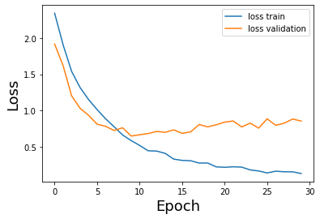

```python
plt.plot(history.history['loss'])
plt.plot(history.history['val_loss'])
plt.xlabel('Epoch', fontsize=18)
plt.ylabel(r'Loss', fontsize=18)
plt.legend(('loss train','loss validation'), loc=0)
```

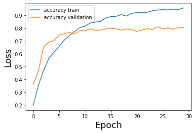

```python
# Print accuracy
plt.plot(history.history['accuracy'])
plt.plot(history.history['val_accuracy'])
plt.xlabel('Epoch', fontsize=18)
plt.ylabel(r'Loss', fontsize=18)
plt.legend(('accuracy train','accuracy validation'), loc=0)
```

**Model Evaluation**

```python
loss, accuracy = model.evaluate(X_test, y_test)
print('Test loss: {:.2f} \n Test accuracy: {:.2f}'.format(loss, accuracy))

loss, accuracy = model.evaluate(X_train, y_train)
print('Train loss: {:.2f} \n Train accuracy: {:.2f}'.format(loss, accuracy))
```

```
Test loss: 0.83
 Test accuracy: 0.78
Train loss: 0.02
 Train accuracy: 0.99
```

Note:

Test Accuracy is 78% Train Accuracy is 99%

Model Retrain

```python
model1 = create_model(input_shape, num_classes)
optimizer = tf.keras.optimizers.Adam(learning_rate=0.001) # Optimizer

model1.compile(optimizer=optimizer,
              loss='categorical_crossentropy',
              metrics=['accuracy'])

model1.summary()
```

```
Model: "sequential_1"
_________________________________________________________________
Layer (type)                 Output Shape              Param #
=================================================================
conv2d_4 (Conv2D)            (None, 128, 128, 32)      896
_________________________________________________________________
max_pooling2d_3 (MaxPooling2 (None, 64, 64, 32)        0
_________________________________________________________________
dropout_5 (Dropout)          (None, 64, 64, 32)        0
_________________________________________________________________
conv2d_5 (Conv2D)            (None, 64, 64, 32)        9248
_________________________________________________________________
conv2d_6 (Conv2D)            (None, 64, 64, 64)        18496
_________________________________________________________________
max_pooling2d_4 (MaxPooling2 (None, 32, 32, 64)        0
_________________________________________________________________
dropout_6 (Dropout)          (None, 32, 32, 64)        0
_________________________________________________________________
conv2d_7 (Conv2D)            (None, 32, 32, 32)        18464
_________________________________________________________________
max_pooling2d_5 (MaxPooling2 (None, 16, 16, 32)        0
_________________________________________________________________
dropout_7 (Dropout)          (None, 16, 16, 32)        0
_________________________________________________________________
flatten_1 (Flatten)          (None, 8192)              0
_________________________________________________________________
dense_3 (Dense)              (None, 512)               4194816
_________________________________________________________________
dropout_8 (Dropout)          (None, 512)               0
_________________________________________________________________
dense_4 (Dense)              (None, 128)               65664
_________________________________________________________________
dropout_9 (Dropout)          (None, 128)               0
_________________________________________________________________
dense_5 (Dense)              (None, 12)                1548
=================================================================
Total params: 4,309,132
Trainable params: 4,309,132
Non-trainable params: 0
_________________________________________________________________
```

```python
history = model1.fit(X_train, y_train, validation_data=(X_val, y_val), epochs=18, callbacks=[callbacks])
```

```python
loss, accuracy = model1.evaluate(X_test, y_test)
print('Test loss: {:.2f} \n Test accuracy: {:.2f}'.format(loss, accuracy))

loss, accuracy = model1.evaluate(X_train, y_train)
print('Train loss: {:.2f} \n Train accuracy: {:.2f}'.format(loss, accuracy))
```

```
Test loss: 0.83
 Test accuracy: 0.76
Train loss: 0.06
 Train accuracy: 0.98
```

Confusion matrix¶

```python
y_pred = model1.predict(X_test)
y_pred = (y_pred > 0.5)
```

```python
print("=== Confusion Matrix ===")
print(confusion_matrix(y_test.argmax(axis=1), y_pred.argmax(axis=1)))
```

```
=== Confusion Matrix ===
[[10  0  0  0  6  0 25  0  0  0  0  0]
 [ 0 51  1  0  0  1  0  1  1  0  0  0]
 [ 5  2 37  1  1  1  0  0  1  0  1  0]
 [ 0  0  0 85  0  0  0  1  2  0  0  0]
 [11  0  0  0 13  1  5  0  3  0  0  0]
 [ 2  2  2  1  0 64  3  0  0  0  0  0]
 [17  0  0  0  3  0 80  0  1  0  0  0]
 [ 3  0  0  2  0  0  0 19  4  0  1  1]
 [ 5  2  1  2  3  0  1  1 54  2  0  3]
 [ 2  0  1  7  0  2  0  1 10 25  0  0]
 [ 2  3  0  1  0  1  2  1  1  2 58  1]
 [ 4  0  2  0  0  1  0  0  3  0  0 37]]
```

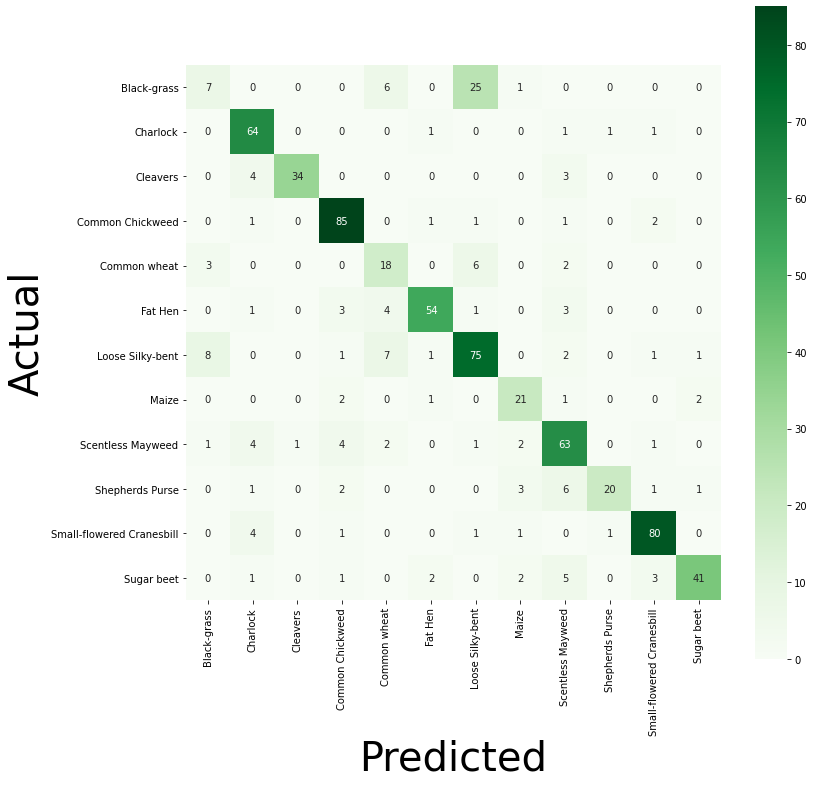

```python
Y_pred = model1.predict(X_val)

Y_pred = np.argmax(Y_pred, axis=1)
Y_true = np.argmax(y_val, axis=1)

cm = confusion_matrix(Y_true, Y_pred)
plt.figure(figsize=(12, 12))
ax = sns.heatmap(cm, cmap=plt.cm.Greens, annot=True, square=True, xticklabels=species, yticklabels=species)
ax.set_ylabel('Actual', fontsize=40)
ax.set_xlabel('Predicted', fontsize=40)
```

```python
print("=== Classification Report ===")
print(classification_report(y_test.argmax(axis=1), y_pred.argmax(axis=1)))
```

```
=== Classification Report ===
              precision    recall  f1-score   support

           0       0.16      0.24      0.20        41
           1       0.85      0.93      0.89        55
           2       0.84      0.76      0.80        49
           3       0.86      0.97      0.91        88
           4       0.50      0.39      0.44        33
           5       0.90      0.86      0.88        74
           6       0.69      0.79      0.74       101
           7       0.79      0.63      0.70        30
           8       0.68      0.73      0.70        74
           9       0.86      0.52      0.65        48
          10       0.97      0.81      0.88        72
          11       0.88      0.79      0.83        47

    accuracy                           0.75       712
   macro avg       0.75      0.70      0.72       712
weighted avg       0.77      0.75      0.75       712
```

Note:

1. Precision: Out of all the positive classes we have predicted correctly, how many are actually positive.
2. Recall: Out of all the positive classes, how much we predicted correctly. It should be high as possible.
3. F1-Score: F1 Score is the weighted average of Precision and Recall. Therefore, this score takes both false positives and false negatives into account. Intuitively it is not as easy to understand as accuracy, but F1 is usually more useful than accuracy, especially if you have an uneven class distribution
4. Precision is performing better than Recall and F1-Score

### 6.Visualize predictions for x_test[2], x_test[3], x_test[33], x_test[36], x_test[59].

```
Predicted label: [ True False False False False False False False False False False False]
```

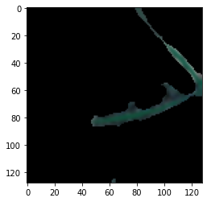

```python
index = 2
plt.imshow(X_test[index], cmap='gray')
print("Predicted label:", y_pred[index])
```

```
Predicted label: [False False False  True False False False False False False False False]
```

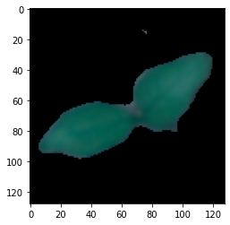

```python
index = 3
plt.imshow(X_test[index], cmap='gray')
print("Predicted label:", y_pred[index])
```

```
Predicted label: [False False False False  True False False False False False False False]
```

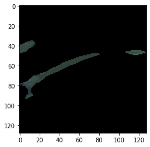

```python
index = 33
plt.imshow(X_test[index], cmap='gray')
print("Predicted label:", y_pred[index])
```

```
Predicted label: [False False False False False False  True False False False False False]
```

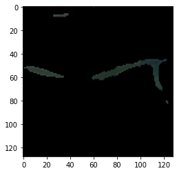

```python
index = 36
plt.imshow(X_test[index], cmap='gray')
print("Predicted label:", y_pred[index])
```

```
Predicted label: [False False False False False False False False False False  True False]
```

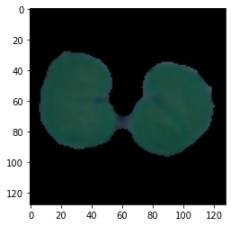

```python
index = 59
plt.imshow(X_test[index], cmap='gray')
print("Predicted label:", y_pred[index])
```

Note: